# Reading Data

```python
#importing the needed libraries
import numpy as np
import pandas as pd
import matplotlib.pyplot as plt
import gc
%matplotlib inline
```

```python
train_data = pd.read_csv('train.csv')
resources_data = pd.read_csv("resources.csv")
#test_data = pd.read_csv('test.csv')
```

```python
#test_data.head()
```

[output not shown]

# Data Discovery

#### Taking a peak at the training data

```python
train_data.head()
```

|  | id | teacher_id | teacher_prefix | school_state | project_submitted_datetime | project_grade_category | project_subject_categories | project_subject_subcategories | project_title | project_essay_1 | project_essay_2 | project_essay_3 | project_essay_4 | project_resource_summary | teacher_number_of_previously_posted_projects | project_is_approved |
| --- | --- | --- | --- | --- | --- | --- | --- | --- | --- | --- | --- | --- | --- | --- | --- | --- |
| 0 | p036502 | 484aaf11257089a66cfedc9461c6bd0a | Ms. | NV | 2016-11-18 14:45:59 | Grades PreK-2 | Literacy & Language | Literacy | Super Sight Word Centers | Most of my kindergarten students come from low... | I currently have a differentiated sight word c... | NaN | NaN | My students need 6 Ipod Nano's to create and d... | 26 | 1 |
| 1 | p039565 | df72a3ba8089423fa8a94be88060f6ed | Mrs. | GA | 2017-04-26 15:57:28 | Grades 3-5 | Music & The Arts, Health & Sports | Performing Arts, Team Sports | Keep Calm and Dance On | Our elementary school is a culturally rich sch... | We strive to provide our diverse population of... | NaN | NaN | My students need matching shirts to wear for d... | 1 | 0 |
| 2 | p233823 | a9b876a9252e08a55e3d894150f75ba3 | Ms. | UT | 2017-01-01 22:57:44 | Grades 3-5 | Math & Science, Literacy & Language | Applied Sciences, Literature & Writing | Lets 3Doodle to Learn | Hello;\r\nMy name is Mrs. Brotherton. I teach ... | We are looking to add some 3Doodler to our cla... | NaN | NaN | My students need the 3doodler. We are an SEM s... | 5 | 1 |
| 3 | p185307 | 525fdbb6ec7f538a48beebaa0a51b24f | Mr. | NC | 2016-08-12 15:42:11 | Grades 3-5 | Health & Sports | Health & Wellness | \"Kid Inspired\" Equipment to Increase Activit... | My students are the greatest students but are ... | The student's project which is totally \"kid-i... | NaN | NaN | My students need balls and other activity equi... | 16 | 0 |
| 4 | p013780 | a63b5547a7239eae4c1872670848e61a | Mr. | CA | 2016-08-06 09:09:11 | Grades 6-8 | Health & Sports | Health & Wellness | We need clean water for our culinary arts class! | My students are athletes and students who are ... | For some reason in our kitchen the water comes... | NaN | NaN | My students need a water filtration system for... | 42 | 1 |

We can see that most of our features are categotical or text so we will probably need lots of feature engineering. Also we can see that there's a possible lots of NaNs in essay 3 & 4, for further inspection lets use describe.

```python
train_data.describe()
```

|  | teacher_number_of_previously_posted_projects | project_is_approved |
| --- | --- | --- |
| count | 182080.000000 | 182080.000000 |
| mean | 11.237055 | 0.847682 |
| std | 28.016086 | 0.359330 |
| min | 0.000000 | 0.000000 |
| 25% | 0.000000 | 1.000000 |
| 50% | 2.000000 | 1.000000 |
| 75% | 9.000000 | 1.000000 |
| max | 451.000000 | 1.000000 |

```python
train_data.describe(include = ['O'])
```

|  | id | teacher_id | teacher_prefix | school_state | project_submitted_datetime | project_grade_category | project_subject_categories | project_subject_subcategories | project_title | project_essay_1 | project_essay_2 | project_essay_3 | project_essay_4 | project_resource_summary |
| --- | --- | --- | --- | --- | --- | --- | --- | --- | --- | --- | --- | --- | --- | --- |
| count | 182080 | 182080 | 182076 | 182080 | 182080 | 182080 | 182080 | 182080 | 182080 | 182080 | 182080 | 6374 | 6374 | 182080 |
| unique | 182080 | 104414 | 5 | 51 | 180439 | 4 | 51 | 407 | 164282 | 147689 | 180984 | 6359 | 6336 | 179730 |
| top | p006980 | fa2f220b537e8653fb48878ebb38044d | Mrs. | CA | 2016-09-01 00:00:03 | Grades PreK-2 | Literacy & Language | Literacy | Flexible Seating | As a teacher in a low-income/high poverty scho... | Students will be using Chromebooks to increase... | Technological literacy is essential if our stu... | Having taught engineering in college, I have c... | My students need electronic tablets to do all ... |
| freq | 1 | 74 | 95405 | 25695 | 30 | 73890 | 39257 | 15775 | 377 | 46 | 24 | 2 | 3 | 84 |

#### Taking a peak at the resources data

```python
resources_data.head(10)
```

|  | id | description | quantity | price |
| --- | --- | --- | --- | --- |
| 0 | p233245 | LC652 - Lakeshore Double-Space Mobile Drying Rack | 1 | 149.00 |
| 1 | p069063 | Bouncy Bands for Desks (Blue support pipes) | 3 | 14.95 |
| 2 | p069063 | Cory Stories: A Kid's Book About Living With Adhd | 1 | 8.45 |
| 3 | p069063 | Dixon Ticonderoga Wood-Cased #2 HB Pencils, Bo... | 2 | 13.59 |
| 4 | p069063 | EDUCATIONAL INSIGHTS FLUORESCENT LIGHT FILTERS... | 3 | 24.95 |
| 5 | p069063 | Last to Finish: A Story About the Smartest Boy... | 1 | 16.99 |
| 6 | p069063 | Mrs. Gorski, I Think I Have the Wiggle Fidgets... | 1 | 9.95 |
| 7 | p069063 | See-N-Read 1503905CQ Reading Tool - Book Size,... | 2 | 10.11 |
| 8 | p096795 | Brewster WPD90218 Wall Pops Flirt Dot, Set of ... | 2 | 9.95 |
| 9 | p096795 | Brewster Wall Pops WPE99065 Peel & Stick Calyp... | 2 | 9.02 |

```python
print(train_data.where(train_data['id']=='p096795').dropna())
```

```
Empty DataFrame
Columns: [id, teacher_id, teacher_prefix, school_state, project_submitted_datetime, project_grade_category, project_subject_categories, project_subject_subcategories, project_title, project_essay_1, project_essay_2, project_essay_3, project_essay_4, project_resource_summary, teacher_number_of_previo…
Index: []
```

```python
resources_data.describe()
```

|  | quantity | price |
| --- | --- | --- |
| count | 1.541272e+06 | 1.541272e+06 |
| mean | 2.860509e+00 | 5.028398e+01 |
| std | 7.570345e+00 | 1.447326e+02 |
| min | 1.000000e+00 | 0.000000e+00 |
| 25% | 1.000000e+00 | 7.900000e+00 |
| 50% | 1.000000e+00 | 1.499000e+01 |
| 75% | 2.000000e+00 | 3.980000e+01 |
| max | 8.000000e+02 | 9.999000e+03 |

```python
resources_data.describe(include=['O'])
```

|  | id | description |
| --- | --- | --- |
| count | 1541272 | 1540980 |
| unique | 260115 | 332928 |
| top | p066966 | Apple - iPad� mini 2 with Wi-Fi - 16GB - Space... |
| freq | 100 | 3037 |

#### Checking missing values

```python
(train_data.isnull().sum()/len(train_data))*100
```

```
id                                               0.000000
teacher_id                                       0.000000
teacher_prefix                                   0.002197
school_state                                     0.000000
project_submitted_datetime                       0.000000
project_grade_category                           0.000000
project_subject_categories                       0.000000
project_subject_subcategories                    0.000000
project_title                                    0.000000
project_essay_1                                  0.000000
project_essay_2                                  0.000000
project_essay_3                                 96.499341
project_essay_4                                 96.499341
project_resource_summary                         0.000000
teacher_number_of_previously_posted_projects     0.000000
project_is_approved                              0.000000
dtype: float64
```

- In training data, we can see that project_essay_4 and project_essay_3 having 96 % null values. so during prediction, better remove these 2 columns.

```python
(resources_data.isnull().sum()/len(train_data))*100
```

```
id             0.000000
description    0.160369
quantity       0.000000
price          0.000000
dtype: float64
```

- In resource data, only description column having few null values. So we can ignore these values.

#### Checking Data balance

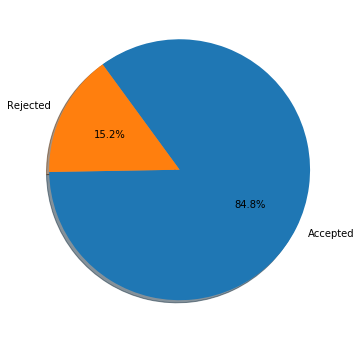

```python
approvedPercentage=(train_data['project_is_approved'].sum() / len(train_data['project_is_approved']))*100
# Pie chart, where the slices will be ordered and plotted counter-clockwise:
labels = 'Accepted', 'Rejected'
sizes = [approvedPercentage, 100 - approvedPercentage]
plt.figure(figsize=(16,6))
plt.pie(sizes, labels=labels, autopct='%1.1f%%', shadow=True, startangle=181)
plt.show()
del approvedPercentage
```

- Training data is highly imbalanced that is approx. 85 % projetcs were approved and 15 % project were not approved. Majority imbalanced class is positive.

#### Histograms & Distributions of some of the features

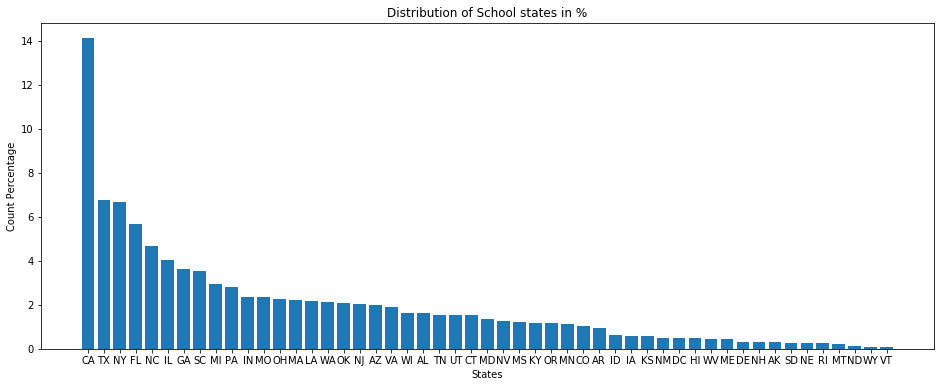

```python
plt.figure(figsize=(16,6))
histData=train_data['school_state'].value_counts()
values = (histData.values/train_data['school_state'].value_counts().sum())*100
plt.bar(histData.index,values)
plt.title('Distribution of School states in %')
plt.xlabel('States')
plt.ylabel('Count Percentage')
plt.show()
del histData
del values
```

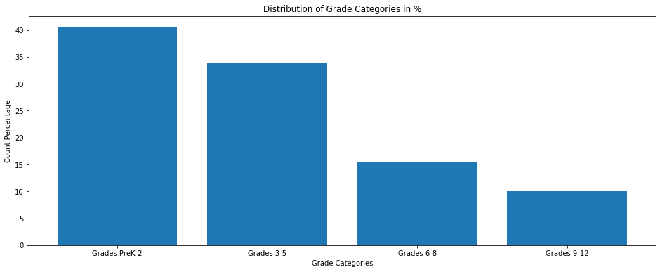

```python
plt.figure(figsize=(16,6))
histData=train_data['project_grade_category'].value_counts()
values = (histData.values/train_data['project_grade_category'].value_counts().sum())*100
plt.bar(histData.index,values)
plt.title('Distribution of Grade Categories in %')
plt.xlabel('Grade Categories')
plt.ylabel('Count Percentage')
plt.show()
del histData
del values
```

- Out of 4 school grade levels, Project proposals submission in school grade levels is higher for Grades Prek-2 which is approximately 41 % followed by Grades 3-5 which has approx. 34 %.

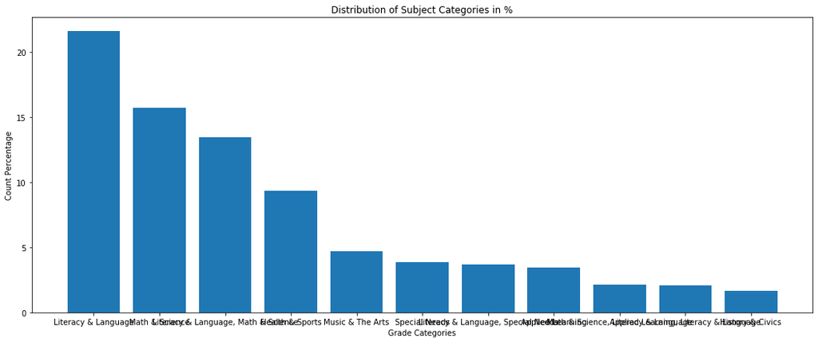

```python
plt.figure(figsize=(18,7))
histData=train_data['project_subject_categories'].value_counts().iloc[0:11]
values = (histData.values/train_data['project_subject_categories'].value_counts().sum())*100
plt.bar(histData.index,values)
plt.title('Distribution of Subject Categories in %')
plt.xlabel('Grade Categories')
plt.ylabel('Count Percentage')
plt.show()
del histData
del values
```

- Out of 51 Project categories, Project proposals submission for project categories is higher for Literacy & Language which is approx. 21.5 % followed by Math & Science which has approx. 15.7 %.

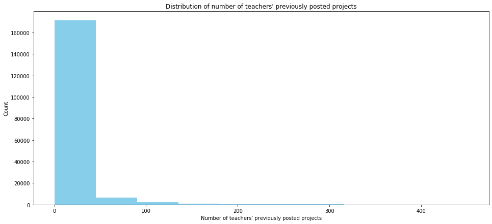

```python
plt.figure(figsize=(16,7))
plt.hist(train_data['teacher_number_of_previously_posted_projects'],color="skyblue")
plt.title('Distribution of number of teachers\' previously posted projects')
plt.xlabel('Number of teachers\' previously posted projects')
plt.ylabel('Count')
plt.show()
```

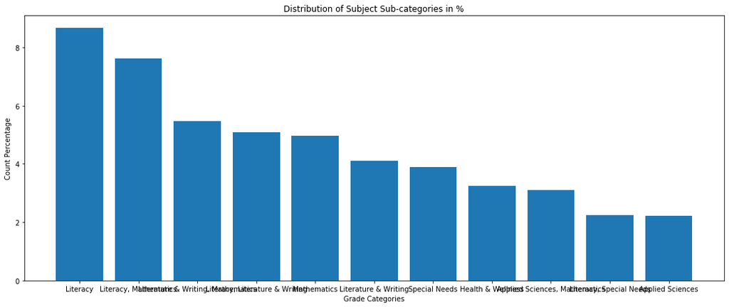

```python
plt.figure(figsize=(18,7))
histData=train_data['project_subject_subcategories'].value_counts().iloc[0:11]
values = (histData.values/train_data['project_subject_subcategories'].value_counts().sum())*100
plt.bar(histData.index,values)
plt.title('Distribution of Subject Sub-categories in %')
plt.xlabel('Grade Categories')
plt.ylabel('Count Percentage')
plt.show()
del histData
del values
```

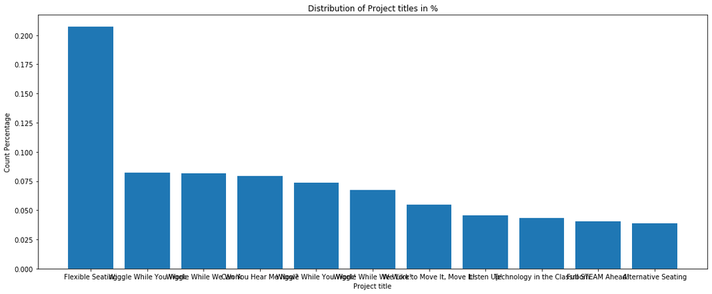

```python
plt.figure(figsize=(18,7))
histData=train_data['project_title'].value_counts().iloc[0:11]
values = (histData.values/train_data['project_title'].value_counts().sum())*100
plt.bar(histData.index,values)
plt.title('Distribution of Project titles in %')
plt.xlabel('Project title')
plt.ylabel('Count Percentage')
plt.show()
del histData
del values
```

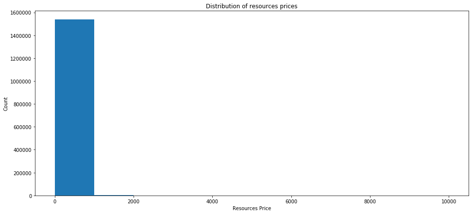

```python
plt.figure(figsize=(16,7))
plt.hist(resources_data['price'])
plt.title('Distribution of resources prices')
plt.xlabel('Resources Price')
plt.ylabel('Count')
plt.show()
```

- There are some items whose price is 0 which looks a little weird but lets hold that thought.
- As we can see most of the price requested for resources is between 0 to 2k dollar.

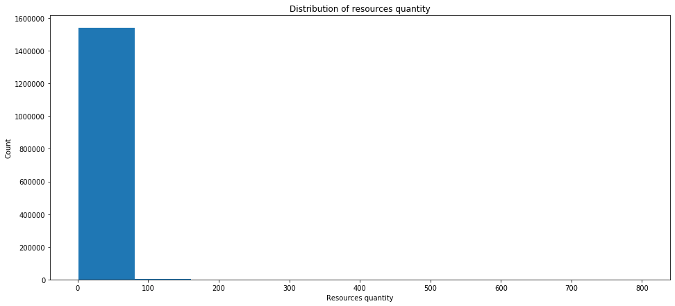

```python
plt.figure(figsize=(16,7))
plt.hist(resources_data['quantity'])
plt.title('Distribution of resources quantity')
plt.xlabel('Resources quantity')
plt.ylabel('Count')
plt.show()
```

[figure not shown]

```python
plt.figure(figsize=(16,7))
plt.hist(train_data['teacher_prefix'].dropna())
plt.title('Distribution of resources quantity')
plt.xlabel('Resources quantity')
plt.ylabel('Count')
plt.show()
```

- Higher number of project proposals are submitted by married women which is approx. 53 % followed by unmarried women which has approx. 37 %.
- Project proposal submitted by Teacher which is approx. 2 % is vey low as compared to Mrs., Ms., Mr.
- There are very few projects submitted by Drs.

### Wordclouds

```python
from os import path
from PIL import Image
from wordcloud import WordCloud, STOPWORDS, ImageColorGenerator
```

#### Resources summary

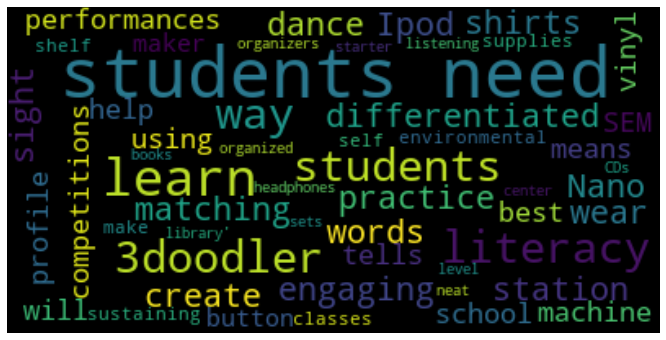

```python
text=train_data['project_resource_summary'].values
wordcloud = WordCloud().generate(str(text))
plt.figure(figsize=(12,6))
plt.imshow(wordcloud, interpolation='bilinear')
plt.axis("off")
plt.show()
del text
del wordcloud
```

#### Resources description

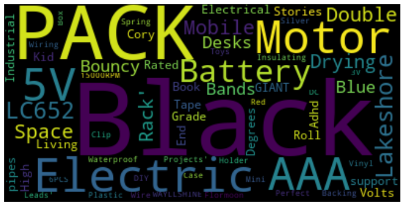

```python
text=resources_data['description'].values
wordcloud = WordCloud().generate(str(text))
plt.figure(figsize=(12,6))
plt.imshow(wordcloud, interpolation='bilinear')
plt.axis("off")
plt.show()
del text
del wordcloud
```

#### Here we compare the word clouds of accepted & rejected proposals for the first essay

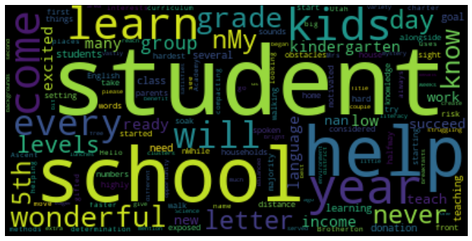

```python
text=train_data.where(train_data['project_is_approved']==1)['project_essay_1'].values
wordcloud = WordCloud().generate(str(text))
plt.figure(figsize=(12,6))
plt.imshow(wordcloud, interpolation='bilinear')
plt.axis("off")
plt.show()
del text
del wordcloud
```

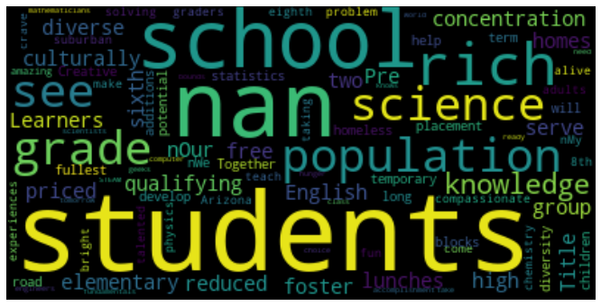

```python
text=train_data.where(train_data['project_is_approved']==0)['project_essay_1'].values
wordcloud = WordCloud().generate(str(text))
plt.figure(figsize=(12,6))
plt.imshow(wordcloud, interpolation='bilinear')
plt.axis("off")
plt.show()
del text
del wordcloud
```

#### Here we compare the word clouds of accepted & rejected proposals for the second essay

[figure not shown]

```python
text=train_data.where(train_data['project_is_approved']==1)['project_essay_2'].values
wordcloud = WordCloud().generate(str(text))
plt.figure(figsize=(12,6))
plt.imshow(wordcloud, interpolation='bilinear')
plt.axis("off")
plt.show()
del text
del wordcloud
```

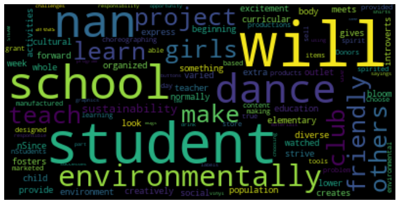

```python
text=train_data.where(train_data['project_is_approved']==0)['project_essay_2'].values
wordcloud = WordCloud().generate(str(text))
plt.figure(figsize=(12,6))
plt.imshow(wordcloud, interpolation='bilinear')
plt.axis("off")
plt.show()
del text
del wordcloud
```

- Student & will exist in both accepted & rejected nearly equally

#### Acceptance Vs Rejection across Different features

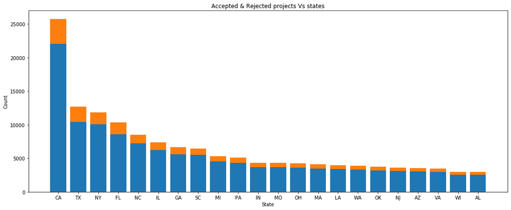

```python
plt.figure(figsize=(18,7))
histData=train_data['school_state'].value_counts().iloc[0:22]
acceptedValues = train_data.where(train_data['project_is_approved']==1)['school_state'].value_counts().iloc[0:22].values
rejectedValues = train_data.where(train_data['project_is_approved']==0)['school_state'].value_counts().iloc[0:22].values
plt.bar(histData.index,acceptedValues)
plt.bar(histData.index,rejectedValues,bottom=acceptedValues)
plt.title('Accepted & Rejected projects Vs states')
plt.xlabel('State')
plt.ylabel('Count')
plt.show()
del histData
del acceptedValues
del rejectedValues
```

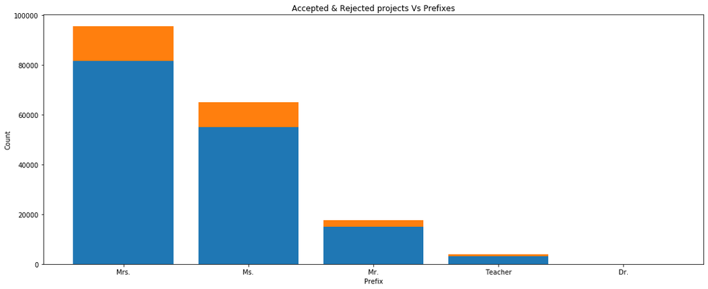

```python
plt.figure(figsize=(18,7))
histData=train_data['teacher_prefix'].value_counts()
acceptedValues = train_data.where(train_data['project_is_approved']==1)['teacher_prefix'].value_counts().values
rejectedValues = train_data.where(train_data['project_is_approved']==0)['teacher_prefix'].value_counts().values
plt.bar(histData.index,acceptedValues)
plt.bar(histData.index,rejectedValues,bottom=acceptedValues)
plt.title('Accepted & Rejected projects Vs Prefixes')
plt.xlabel('Prefix')
plt.ylabel('Count')
plt.show()
del histData
del acceptedValues
del rejectedValues
```

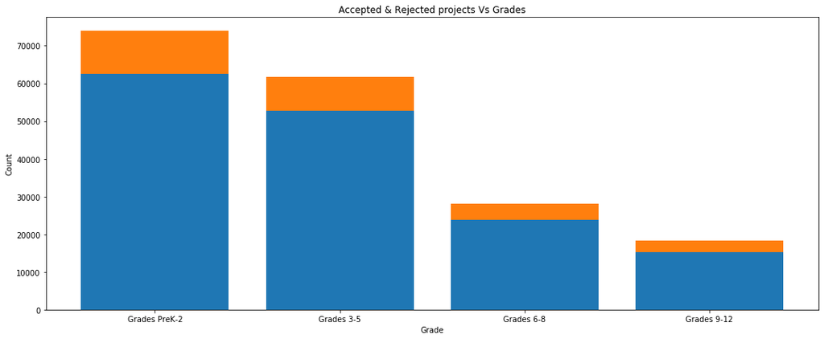

```python
plt.figure(figsize=(18,7))
histData=train_data['project_grade_category'].value_counts()
acceptedValues = train_data.where(train_data['project_is_approved']==1)['project_grade_category'].value_counts().values
rejectedValues = train_data.where(train_data['project_is_approved']==0)['project_grade_category'].value_counts().values
plt.bar(histData.index,acceptedValues)
plt.bar(histData.index,rejectedValues,bottom=acceptedValues)
plt.title('Accepted & Rejected projects Vs Grades')
plt.xlabel('Grade')
plt.ylabel('Count')
plt.show()
del histData
del acceptedValues
del rejectedValues
```

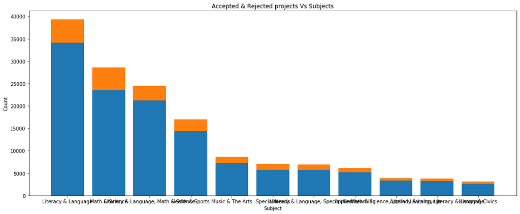

```python
plt.figure(figsize=(18,7))
histData=train_data['project_subject_categories'].value_counts().iloc[0:11]
acceptedValues = train_data.where(train_data['project_is_approved']==1)['project_subject_categories'].value_counts().iloc[0:11].values
rejectedValues = train_data.where(train_data['project_is_approved']==0)['project_subject_categories'].value_counts().iloc[0:11].values
plt.bar(histData.index,acceptedValues)
plt.bar(histData.index,rejectedValues,bottom=acceptedValues)
plt.title('Accepted & Rejected projects Vs Subjects')
plt.xlabel('Subject')
plt.ylabel('Count')
plt.show()
del histData
del acceptedValues
del rejectedValues
```

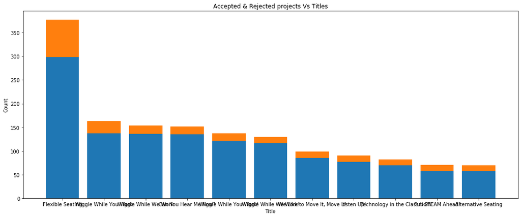

```python
plt.figure(figsize=(18,7))
histData=train_data['project_title'].value_counts().iloc[0:11]
acceptedValues = train_data.where(train_data['project_is_approved']==1)['project_title'].value_counts().iloc[0:11].values
rejectedValues = train_data.where(train_data['project_is_approved']==0)['project_title'].value_counts().iloc[0:11].values
plt.bar(histData.index,acceptedValues)
plt.bar(histData.index,rejectedValues,bottom=acceptedValues)
plt.title('Accepted & Rejected projects Vs Titles')
plt.xlabel('Title')
plt.ylabel('Count')
plt.show()
del histData
```

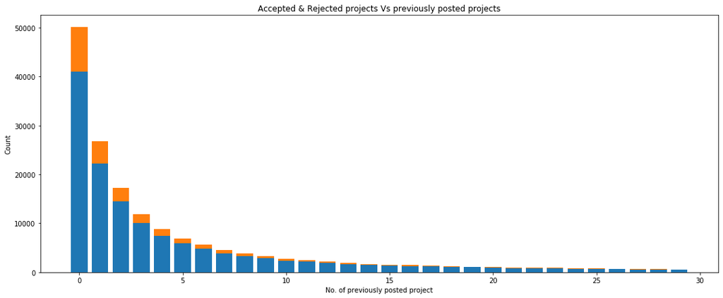

```python
plt.figure(figsize=(18,7))
histData=train_data['teacher_number_of_previously_posted_projects'].value_counts()

acceptedData=train_data.where(train_data['project_is_approved']==1)['teacher_number_of_previously_posted_projects'].value_counts()
rejectedData=train_data.where(train_data['project_is_approved']==0)['teacher_number_of_previously_posted_projects'].value_counts()
sortedAccepted=acceptedData.sort_index()
sortedRejected=rejectedData.sort_index()
sortedData=histData.sort_index()

for index in sortedData.index:

    if index not in sortedAccepted.index:
        sortedAccepted[float(index)]=0

    if index not in sortedRejected.index:
        sortedRejected[float(index)]=0


plt.bar(sortedAccepted.iloc[0:30].index,sortedAccepted.iloc[0:30].values)
plt.bar(sortedRejected.iloc[0:30].index,sortedRejected.iloc[0:30].values,bottom=sortedAccepted.iloc[0:30].values)
plt.title('Accepted & Rejected projects Vs previously posted projects')
plt.xlabel('No. of previously posted project')
plt.ylabel('Count')
plt.show()
del histData
del sortedAccepted
del sortedRejected
del sortedData
```

- We can see that even teachers with 0 previously posted projects have high acceptance rate.

### Time series analysis

```python
from datetime import datetime
def dateStrToMonth(series):
    monthsArr=[]
    for e in series:
        eDate=datetime.strptime(e, '%Y-%m-%d %H:%M:%S')
        monthsArr.append(eDate.month)
    return pd.Series(monthsArr)
```

```python
dateAccepted_str=train_data.where(train_data['project_is_approved']==1)['project_submitted_datetime'].dropna()
dateRejected_str=train_data.where(train_data['project_is_approved']==0)['project_submitted_datetime'].dropna()
dateArrRejected=dateStrToMonth(dateRejected_str)
dateArrAccepted=dateStrToMonth(dateAccepted_str)
```

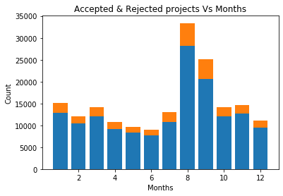

```python
acceptedMonths=dateArrAccepted.value_counts(sort=False).sort_index()
rejectedMonths=dateArrRejected.value_counts(sort=False).sort_index()

plt.bar(acceptedMonths.index,acceptedMonths.values)
plt.bar(rejectedMonths.index,rejectedMonths.values,bottom=acceptedMonths.values)
plt.title('Accepted & Rejected projects Vs Months')
plt.xlabel('Months')
plt.ylabel('Count')
plt.show()
del dateArrRejected
del dateArrAccepted
del acceptedMonths
del rejectedMonths
```

```python
def dateStrToWeekDay(series):
    daysArr=[]
    for e in series:
        eDate=datetime.strptime(e, '%Y-%m-%d %H:%M:%S')
        daysArr.append(eDate.weekday())
    return pd.Series(daysArr)
```

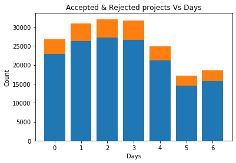

```python
dayArrRejected=dateStrToWeekDay(dateRejected_str)
dayArrAccepted=dateStrToWeekDay(dateAccepted_str)
acceptedDays=dayArrAccepted.value_counts(sort=False).sort_index()
rejectedDays=dayArrRejected.value_counts(sort=False).sort_index()

plt.bar(acceptedDays.index,acceptedDays.values)
plt.bar(rejectedDays.index,rejectedDays.values,bottom=acceptedDays.values)
plt.title('Accepted & Rejected projects Vs Days')
plt.xlabel('Days')
plt.ylabel('Count')
plt.show()
del dayArrRejected
del dayArrAccepted
del acceptedDays
del rejectedDays
```

- The number of proposals decreases as we move towards the end of the week.

```python
def strToDateSeries(series):
    daysArr=[]
    for e in series:
        eDate=datetime.strptime(e, '%Y-%m-%d %H:%M:%S')
        daysArr.append(eDate.date())
    return pd.Series(daysArr)
```

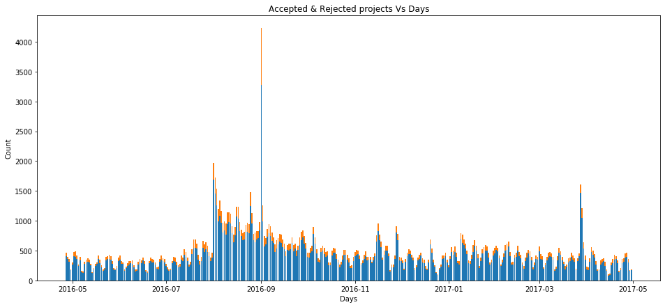

```python
dateArrRejected=strToDateSeries(dateRejected_str)
dateArrAccepted=strToDateSeries(dateAccepted_str)
acceptedDates=dateArrAccepted.value_counts(sort=False).sort_index()
rejectedDates=dateArrRejected.value_counts(sort=False).sort_index()

plt.figure(figsize=(16,7))
plt.bar(acceptedDates.index,acceptedDates.values)
plt.bar(rejectedDates.index,rejectedDates.values,bottom=acceptedDates.values)
plt.title('Accepted & Rejected projects Vs Days')
plt.xlabel('Days')
plt.ylabel('Count')
plt.show()
del acceptedValues
del rejectedValues
del dateArrRejected
del dateArrAccepted
del acceptedDates
del rejectedDates
del dateAccepted_str
del dateRejected_str
```

- Looks like we have approximately one years' worth of data (May 2016 to April 2017) given in the training set.
- There is a sudden spike on a single day (Sep 1, 2016) with respect to the number of proposals (may be some specific reason?)

# Feature Engineering

#### We will create 4 features from project_submitted_datetime:

- year
- month
- weekday
- hour

```python
def dateStrToYear(series):
    daysArr=[]
    for e in series:
        eDate=datetime.strptime(e, '%Y-%m-%d %H:%M:%S')
        daysArr.append(eDate.year)
    return pd.Series(daysArr)
```

```python
def dateStrToHour(series):
    daysArr=[]
    for e in series:
        eDate=datetime.strptime(e, '%Y-%m-%d %H:%M:%S')
        daysArr.append(eDate.hour)
    return pd.Series(daysArr)
```

```python
train_data['year'] = dateStrToYear(train_data['project_submitted_datetime'])
train_data['month'] = dateStrToMonth(train_data['project_submitted_datetime'])
train_data['weekday'] = dateStrToWeekDay(train_data['project_submitted_datetime'])
train_data['hour'] = dateStrToHour(train_data['project_submitted_datetime'])
```

```python
#test_data['year'] = dateStrToYear(test_data['project_submitted_datetime'])
#test_data['month'] = dateStrToMonth(test_data['project_submitted_datetime'])
#test_data['weekday'] = dateStrToWeekDay(test_data['project_submitted_datetime'])
#test_data['hour'] = dateStrToHour(test_data['project_submitted_datetime'])
```

```python
train_data['e1_length'] = train_data['project_essay_1'].str.len()
train_data['e2_length'] = train_data['project_essay_2'].str.len()
train_data['project_title_len'] = train_data['project_title'].str.len()
train_data['project_resource_summary_len'] = train_data['project_resource_summary'].str.len()
#Here we need to use a function that counts words
train_data['e1_word_count'] = train_data['project_essay_1'].str.split().str.len()
train_data['e2_word_count'] = train_data['project_essay_2'].str.split().str.len()
train_data['project_title_word_count'] = train_data['project_title'].str.split().str.len()
train_data['project_resource_summary_word_count'] = train_data['project_resource_summary'].str.split().str.len()
#add word density for description as well
```

```python
#test_data['e1_length'] = test_data['project_essay_1'].str.len()
#test_data['e2_length'] = test_data['project_essay_2'].str.len()
#test_data['project_title_len'] = test_data['project_title'].str.len()
#test_data['project_resource_summary_len'] = test_data['project_resource_summary'].str.len()
#Here we need to use a function that counts words
#test_data['e1_word_count'] = test_data['project_essay_1'].str.split().str.len()
#test_data['e2_word_count'] = test_data['project_essay_2'].str.split().str.len()
#test_data['project_title_word_count'] = test_data['project_title'].str.split().str.len()
#test_data['project_resource_summary_word_count'] = test_data['project_resource_summary'].str.split().str.len()
#add word density for description as well
```

```python
from nltk.corpus import stopwords
import re

#takes string s & array of stopwords that you want to add to the default stop words
def cleanString(s,specialStopWords=[],bivariate=False):
    s=s.lower()
    s=re.sub('[^A-Za-z0-9\s]+', '', s)
    sTokenized= s.split()
    myStopWords = stopwords.words('english')
    for word in specialStopWords:
        myStopWords.append(word)
    if bivariate:
        cleanS = [word for word in sTokenized if word not in myStopWords and word != 'nan']
        s =' '.join(cleanS)
        cleanS = re.findall("[^\s]+\s[^\s]+", s) + re.findall("[^\s]+\s[^\s]+", s[s.find(' '):])
    else:
        cleanS = [word for word in sTokenized if word not in myStopWords]
    return pd.Series(cleanS)
#takes string s & array of stopwords that you want to add to the default stop words
def wordDensity(s,specialStopWords=[],bivariate=False):
    s=cleanString(s,specialStopWords,bivariate)
    histData=s.value_counts()
    wordsNum=histData.values.sum()
    density=histData[0:20].values/wordsNum
    return pd.Series(data=density,index=histData.index[0:20])
#Takes two serieses and returns an array of the common indecies
def getSpecialStopWords(s1,s2,eps=1):
    sWords=[x for x in s1.index if x in s2.index and abs(s1[x]-s2[x])<=eps]
    return sWords
```

```python
def topWords(featureSeries, labelSeries, prefix='',eps=1, n=10, bivariate=False):
    #This function returns the top words in featureSeries (both approved & rejected) according to densities

    #Get top n words in the approved set
    text1=featureSeries.where(labelSeries==1).str.cat(sep=' ')
    approved=wordDensity(text1,bivariate=bivariate)[0:n]

    #Get top n words in the rejected set
    text0=featureSeries.where(labelSeries==0).str.cat(sep=' ')
    rejected=wordDensity(text0,bivariate=bivariate)[0:n]

    #Get common words between them
    SSW=getSpecialStopWords(approved,rejected,eps)

    #Get n top words from each set
    approved = wordDensity(text1,SSW,bivariate=bivariate)[0:n+10]
    rejected = wordDensity(text0,SSW,bivariate=bivariate)[0:n+10]

    #Adding prefix
    approved.index= prefix + approved.index
    rejected.index= prefix + rejected.index

    #print(approved.index)
    #print(rejected.index)
    fullList=set(approved.index.append(rejected.index))
    #Concatenate them to get the full list
    return list(fullList)
```

# Refactored Code

```python
e1_topwords=topWords(train_data['project_essay_1'],train_data['project_is_approved'],prefix='e1_')
e2_topwords=topWords(train_data['project_essay_2'],train_data['project_is_approved'],prefix='e2_')
project_title_topwords=topWords(train_data['project_title'],train_data['project_is_approved'],prefix='project_title_')
project_resource_summary_topwords=topWords(train_data['project_resource_summary'],train_data['project_is_approved'],prefix='project_resource_summary_')
```

#### We create a list of all the indices (combine those from each feature)

```python
initArray=np.zeros(train_data.shape[0])

#Change it to a list of the indices instead of being a series
wordsFeaturesExtractedFromDensity = project_resource_summary_topwords + project_title_topwords + e1_topwords + e2_topwords
wordsFeaturesExtractedFromDensity
```

#### Here we use the list to add these indices to the dataset & initialize them to 0 values so that we can insert values in them later

```python
#So here we need to initialize the 80 columns now.
for keyword in wordsFeaturesExtractedFromDensity:
    train_data[keyword]=pd.Series(initArray)
```

```python
#So here we need to initialize the 80 columns now.
#for keyword in wordsFeaturesExtractedFromDensity:
#    test_data[keyword]=pd.Series(initArray)
del initArray
```

```python
train_data.head()
```

#### Extracting values for univariate words in Essay 1

```python
for index, text in train_data.project_essay_1.items():
    density=wordDensity(text)
    for word, value in density.items():
        word2='e1_'+word
        if word2 in e1_topwords:
            train_data[word2][index] = value
```

#### Extracting values for univariate words in Essay 2

```python
for index, text in train_data.project_essay_2.items():
    density=wordDensity(text)
    for word, value in density.items():
        word2='e2_'+word
        if word2 in e2_topwords:
            train_data[word2][index] = value
```

#### Extracting values for univariate words in Project_title

```python
for index, text in train_data.project_title.items():
    density=wordDensity(text)
    for word, value in density.items():
        word2='project_title_'+word
        if word2 in project_title_topwords:
            train_data[word2][index] = value
```

#### Extracting values for univariate words in Project_resource_summary

```python
for index, text in train_data.project_resource_summary.items():
    density=wordDensity(text)
    for word, value in density.items():
        word2='project_resource_summary_'+word
        if word2 in project_resource_summary_topwords:
            train_data[word2][index] = value
```

```python
#for index, text in test_data.project_essay_1.items():
 #   density=wordDensity(text)
  #  for word, value in density.items():
   #     word2='e1_'+word
    #    if word2 in e1_topwords:
     #       test_data[word2][index] = value
```

#### Extracting values for univariate words in Essay 2

```python
#for index, text in test_data.project_essay_2.items():
 #   density=wordDensity(text)
  #  for word, value in density.items():
   #     word2='e2_'+word
    #    if word2 in e2_topwords:
     #       test_data[word2][index] = value
```

#### Extracting values for univariate words in Project_title

```python
#for index, text in test_data.project_title.items():
 #   density=wordDensity(text)
  #  for word, value in density.items():
   #     word2='project_title_'+word
    #    if word2 in project_title_topwords:
     #       test_data[word2][index] = value
```

#### Extracting values for univariate words in Project_resource_summary

```python
#for index, text in test_data.project_resource_summary.items():
 #   density=wordDensity(text)
  #  for word, value in density.items():
   #     word2='project_resource_summary_'+word
    #    if word2 in project_resource_summary_topwords:
     #       test_data[word2][index] = value
```

### Bivariate word density

```python
e1_topwords=topWords(train_data['project_essay_1'],train_data['project_is_approved'],prefix='e1_',bivariate=True)
e2_topwords=topWords(train_data['project_essay_2'],train_data['project_is_approved'],prefix='e2_',bivariate=True)
project_title_topwords=topWords(train_data['project_title'],train_data['project_is_approved'],prefix='project_title_',bivariate=True)
project_resource_summary_topwords=topWords(train_data['project_resource_summary'],train_data['project_is_approved'],prefix='project_resource_summary_',bivariate=True)
```

#### We create a list of all the indices (combine those from each feature)

```python
initArray=np.zeros(train_data.shape[0])

#Change it to a list of the indices instead of being a series
wordsFeaturesExtractedFromDensity = project_resource_summary_topwords + project_title_topwords + e1_topwords + e2_topwords
wordsFeaturesExtractedFromDensity
```

#### Here we use the list to add these indices to the dataset & initialize them to 0 values so that we can insert values in them later

```python
for keyword in wordsFeaturesExtractedFromDensity:
    train_data[keyword]=pd.Series(initArray)
```

```python
#for keyword in wordsFeaturesExtractedFromDensity:
 #   test_data[keyword]=pd.Series(initArray)
del initArray
```

#### Extracting values for bivariate words in Essay 1

```python
for index, text in train_data.project_essay_1.items():
    density=wordDensity(text,bivariate=True)
    for word, value in density.items():
        word2='e1_'+word
        if word2 in e1_topwords:
            train_data[word2][index] = value
```

#### Extracting values for bivariate words in Essay 2

```python
for index, text in train_data.project_essay_2.items():
    density=wordDensity(text,bivariate=True)
    for word, value in density.items():
        word2='e2_'+word
        if word2 in e2_topwords:
            train_data[word2][index] = value
```

#### Extracting values for bivariate words in Project_title

```python
for index, text in train_data.project_title.items():
    density=wordDensity(text,bivariate=True)
    for word, value in density.items():
        word2='project_title_'+word
        if word2 in project_title_topwords:
            train_data[word2][index] = value
```

#### Extracting values for bivariate words in Project_resource_summary

```python
for index, text in train_data.project_resource_summary.items():
    density=wordDensity(text,bivariate=True)
    for word, value in density.items():
        word2='project_resource_summary_'+word
        if word2 in project_resource_summary_topwords:
            train_data[word2][index] = value
```

```python
#for index, text in test_data.project_essay_1.items():
 #   density=wordDensity(text,bivariate=True)
  #  for word, value in density.items():
   #     word2='e1_'+word
    #    if word2 in e1_topwords:
     #       test_data[word2][index] = value
```

#### Extracting values for bivariate words in Essay 2

```python
#for index, text in test_data.project_essay_2.items():
 #   density=wordDensity(text,bivariate=True)
  #  for word, value in density.items():
   #     word2='e2_'+word
    #    if word2 in e2_topwords:
     #       test_data[word2][index] = value
```

#### Extracting values for bivariate words in Project_title

```python
#for index, text in test_data.project_title.items():
 #   density=wordDensity(text,bivariate=True)
  #  for word, value in density.items():
   #     word2='project_title_'+word
    #    if word2 in project_title_topwords:
     #       test_data[word2][index] = value
```

#### Extracting values for bivariate words in Project_resource_summary

```python
#for index, text in test_data.project_resource_summary.items():
 #   density=wordDensity(text,bivariate=True)
  #  for word, value in density.items():
   #     word2='project_resource_summary_'+word
    #    if word2 in project_resource_summary_topwords:
     #       test_data[word2][index] = value
```

```python
train_data.head()
```

#### We will create 6 Categorical features :

- teacher_prefix
- teacher_id
- school_state
- project_grade_category
- project_subject_categories
- project_subject_subcategories

```python
#teacher_prefix
train_data=train_data.join(train_data['teacher_prefix'].str.get_dummies())
```

```python
#project_grade_category
train_data=train_data.join(train_data['project_grade_category'].str.get_dummies())
```

```python
#count_maps
school_state_counts=train_data['school_state'].value_counts().to_dict()
project_subject_categories_counts=train_data['project_subject_categories'].value_counts().to_dict()
project_subject_subcategories_counts=train_data['project_subject_subcategories'].value_counts().to_dict()
teacher_id_counts=train_data['teacher_id'].value_counts().to_dict()
```

```python
#For school_state & cats just use the count method
#For the id we will just ignore it.
train_data['school_state']=train_data['school_state'].map(school_state_counts)
train_data['project_subject_categories']=train_data['project_subject_categories'].map(project_subject_categories_counts)
train_data['project_subject_subcategories']=train_data['project_subject_subcategories'].map(project_subject_subcategories_counts)
train_data['teacher_id']=train_data['teacher_id'].map(teacher_id_counts)
```

#### Dropping useless features

```python
#dropping processed categorical columns
train_data.drop(columns=['teacher_prefix','project_grade_category'],inplace=True)
#dropping essay 3 & 4 as they have more than 96% nans
train_data.drop(columns=['project_essay_1','project_essay_2','project_essay_3','project_essay_4'],inplace=True)
#dropping datetime
train_data.drop(columns=['project_submitted_datetime'],inplace=True)
```

#### Adding features from resources_data

```python
resources_agg=resources_data.groupby(['id']).sum()
resources_mean=resources_data.groupby(['id']).mean()
resources_count=resources_data.groupby(['id']).count()
```

```python
resources=resources_agg.join(resources_mean,rsuffix='_mean').join(resources_count,rsuffix='_count')
resources.drop(columns=['quantity_count','price_count'],inplace=True)
resources.rename(columns={'description':'resources_count'},inplace=True)
```

```python
train_data=train_data.join(resources,on='id')
```

#### We need to one hot encode year, month, weekday & hour

```python
train_data=train_data.join(pd.get_dummies(train_data['year']) ,rsuffix='_year').join(pd.get_dummies(train_data['month']),rsuffix='_month').join(pd.get_dummies(train_data['weekday']),rsuffix='_weekday').join(pd.get_dummies(train_data['hour']),rsuffix='_hour')
```

#### We need to drop id, project_title, year, month, weekday, hour & summary

```python
train_data.drop(columns=['year','month','weekday','hour','id','project_title','project_resource_summary'],inplace=True)
```

```python
#teacher_prefix
#test_data=test_data.join(test_data['teacher_prefix'].str.get_dummies())
```

```python
#project_grade_category
#test_data=test_data.join(test_data['project_grade_category'].str.get_dummies())
```

```python
#count_maps
#school_state_counts=test_data['school_state'].value_counts().to_dict()
#project_subject_categories_counts=test_data['project_subject_categories'].value_counts().to_dict()
#project_subject_subcategories_counts=test_data['project_subject_subcategories'].value_counts().to_dict()
#teacher_id_counts=test_data['teacher_id'].value_counts().to_dict()
```

```python
#For school_state & cats just use the count method
#For the id we will just ignore it.
#test_data['school_state']=test_data['school_state'].map(school_state_counts)
#test_data['project_subject_categories']=test_data['project_subject_categories'].map(project_subject_categories_counts)
#test_data['project_subject_subcategories']=test_data['project_subject_subcategories'].map(project_subject_subcategories_counts)
#test_data['teacher_id']=test_data['teacher_id'].map(teacher_id_counts)
```

#### Dropping useless features

```python
#dropping processed categorical columns
#test_data.drop(columns=['teacher_prefix','project_grade_category'],inplace=True)
#dropping essay 3 & 4 as they have more than 96% nans
#test_data.drop(columns=['project_essay_1','project_essay_2','project_essay_3','project_essay_4'],inplace=True)
#dropping datetime
#test_data.drop(columns=['project_submitted_datetime'],inplace=True)
```

#### Adding features from resources_data

```python
#test_data=test_data.join(resources,on='id')
```

#### We need to one hot encode year, month, weekday & hour

```python
#test_data=test_data.join(pd.get_dummies(test_data['year']) ,rsuffix='_year').join(pd.get_dummies(test_data['month']),rsuffix='_month').join(pd.get_dummies(test_data['weekday']),rsuffix='_weekday').join(pd.get_dummies(test_data['hour']),rsuffix='_hour')
```

#### We need to drop id, project_title, year, month, weekday, hour & summary

```python
#test_data.drop(columns=['year','month','weekday','hour','id','project_title','project_resource_summary'],inplace=True)
```

```python
#test_data.head()
```

```python
from sklearn.linear_model import LogisticRegression
import sklearn.metrics as metrics
from sklearn.model_selection import train_test_split
```

```python
#train_data.to_csv('processed_train_data.csv',index=False)
#test_data.to_csv('processed_test_data.csv',index=False)
```

```python
#importing the needed libraries
#import numpy as np
#import pandas as pd
#import matplotlib.pyplot as plt
#import gc
#from sklearn.linear_model import LogisticRegression
#import sklearn.metrics as metrics
#from sklearn.model_selection import train_test_split
#from nltk.corpus import stopwords
#import re
#from os import path
#from PIL import Image
#from wordcloud import WordCloud, STOPWORDS, ImageColorGenerator
#%matplotlib inline
#processed_data=pd.read_csv('processed_train_data.csv')
#processed_data.head()
```

[output not shown]

## Building our baseline

```python
#Split data to features and labels
features=np.array(train_data['teacher_number_of_previously_posted_projects']).reshape(-1, 1)
labels=np.array(train_data['project_is_approved'])
#X_test=np.array(test_data['teacher_number_of_previously_posted_projects']).reshape(-1, 1)
#y_test=np.array(test_data['project_is_approved'])

X_train, X_test, y_train, y_test = train_test_split( features, labels, test_size=0.2, random_state=42)

#Choose a model
benchmark_model=LogisticRegression(random_state=42, solver='saga')
#train the model using only previously posted projects
benchmark_model.fit(X_train,y_train)
#test the model
y_pred = benchmark_model.predict_proba(X_test)
#print(y_pred.reshape(1, -1)[0][0::2])
#Check results
fpr_bl, tpr_bl, thresholds_bl = metrics.roc_curve(y_test, y_pred.reshape(1, -1)[0][1::2])
#print(fpr)
roc_auc_bl = metrics.auc(fpr_bl, tpr_bl)
```

#### Now that we have our baseline, let's build a better model

```python
import lightgbm as lgb
from sklearn.metrics import precision_score
from sklearn.metrics import recall_score
from sklearn.metrics import accuracy_score
#Split data to features and labels
features=train_data.drop(columns=['project_is_approved'])
labels=np.array(train_data['project_is_approved'])
#X_test=test_data.drop(columns=['project_is_approved'])
#y_test=np.array(test_data['project_is_approved'])

X_train, X_test, y_train, y_test = train_test_split( features, labels, test_size=0.2, random_state=42)


#Constructing the model
gbm = lgb.LGBMClassifier(num_leaves=31,
                        learning_rate=0.029,
                        n_estimators=400,
                        max_depth=5)
#Training the model
gbm.fit(X_train, y_train,
        eval_set=[(X_test, y_test)],
        eval_metric='auc',
        early_stopping_rounds=5)
#Predicting
y_pred = gbm.predict_proba(X_test, num_iteration=gbm.best_iteration_)
y_pred2 = gbm.predict(X_test, num_iteration=gbm.best_iteration_)
#print(y_pred.reshape(1, -1)[0][0::2])
#Evaluate Model
fpr, tpr, thresholds = metrics.roc_curve(y_test, y_pred.reshape(1, -1)[0][1::2])
#print(fpr)
roc_auc = metrics.auc(fpr, tpr)
print(precision_score(y_test, y_pred2))
print(recall_score(y_test, y_pred2))
print(accuracy_score(y_test, y_pred2))
```

[output not shown]

[output cut: 331 more lines]

```
[371]	valid_0's auc: 0.742659	valid_0's binary_logloss: 0.376719
[372]	valid_0's auc: 0.742686	valid_0's binary_logloss: 0.376715
[373]	valid_0's auc: 0.742733	valid_0's binary_logloss: 0.376697
[374]	valid_0's auc: 0.742747	valid_0's binary_logloss: 0.37669
[375]	valid_0's auc: 0.742776	valid_0's binary_logloss: 0.376681
[376]	valid_0's auc: 0.742761	valid_0's binary_logloss: 0.376684
[377]	valid_0's auc: 0.742766	valid_0's binary_logloss: 0.376684
[378]	valid_0's auc: 0.742777	valid_0's binary_logloss: 0.376686
[379]	valid_0's auc: 0.74278	valid_0's binary_logloss: 0.376685
[380]	valid_0's auc: 0.742767	valid_0's binary_logloss: 0.376688
Early stopping, best iteration is:
[375]	valid_0's auc: 0.742776	valid_0's binary_logloss: 0.376681
0.8534083941809264
0.99296345536496
0.8495990773286467
```

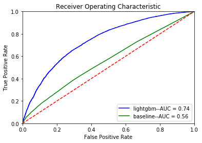

```python
plt.title('Receiver Operating Characteristic')
plt.plot(fpr, tpr, 'b', label = 'lightgbm--AUC = %0.2f' % roc_auc)
plt.plot(fpr_bl, tpr_bl, color='green', label = 'baseline--AUC = %0.2f' % roc_auc_bl)
plt.legend(loc = 'lower right')
plt.plot([0, 1], [0, 1],'r--')
plt.xlim([0, 1])
plt.ylim([0, 1])
plt.ylabel('True Positive Rate')
plt.xlabel('False Positive Rate')
plt.show()
```

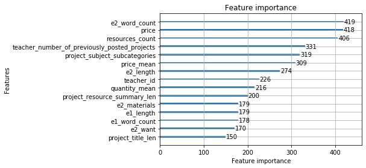

```python
lgb.plot_importance(gbm,max_num_features=15)
```

```python
from keras.models import Sequential
from keras.layers import Dense, Activation
model = Sequential()
model.add(Dense(32, input_dim=266))
model.add(Activation('sigmoid'))
model.add(Dense(16))
model.add(Activation('sigmoid'))
model.add(Dense(8))
model.add(Activation('sigmoid'))
model.add(Dense(1))
model.add(Activation('sigmoid'))
```

```python
model.compile(optimizer='rmsprop',loss='binary_crossentropy', metrics=['accuracy'])
```

```python
model.fit(X_train, np.array(y_train), epochs=10, batch_size=100,verbose=1)
```

```
<keras.callbacks.callbacks.History at 0x26a716d7dc8>
```

```python
y_predNN=model.predict_proba(X_test)
fpr, tpr, thresholds = metrics.roc_curve(y_test, y_predNN)
#print(fpr)
print(metrics.auc(fpr, tpr))
#y_predNN
```

```
0.5001392820799815
```